# Introduction to Categorical Data Analysis…in R!

## About me

- Alejandra Rodríguez Sánchez
- Second year, PhD candidate in Sociology here at HU
- Master in Statistics, HU + MA RTP, HU + Bachelors in Economics and Sociology (Univalle, Colombia)
- Research topic: Family dynamics and social class effects on children’s education
- Supervised by: Prof. Dr. Anette Fasang
- Hobbies: stats + literature + tennis

## Categorical Data Analysis

- What is categorical data?

“A *categorical variable* has a measurement scale consisting of a set of categories”

Agresti (2002, 1)

“We live in a categorical world! From a positive or negative disease diagnosis to choosing all items that apply in a survey, outcomes are frequently organized into categories so that people can more easily make sense of them”

Bilder and Loughin (2014, ix)

“In statistics, a categorical variable is a variable that can take on one of a limited, and usually fixed number of possible values, assigning each individual or other unit of observation to a particular group or nominal category on the basis of some qualitative property.”

(Wikipedia entry for *Categorical variable*, accessed on the 20-Oct-2019)

## Categorical Data Analysis II

So it seems categorical data analysis is defined by the type of data…

- Discrete v. Continuous
- In R: float, numeric, factor, logical, character types

A well known hierarchy (though controversial) of variable types goes something like this:

1. Qualitative information
2. Binary and nominal
3. Ordinal
4. Discrete or count
5. Interval
6. Ratio

## Examples of categorical data

## Example No. 1

- SOEP 2018

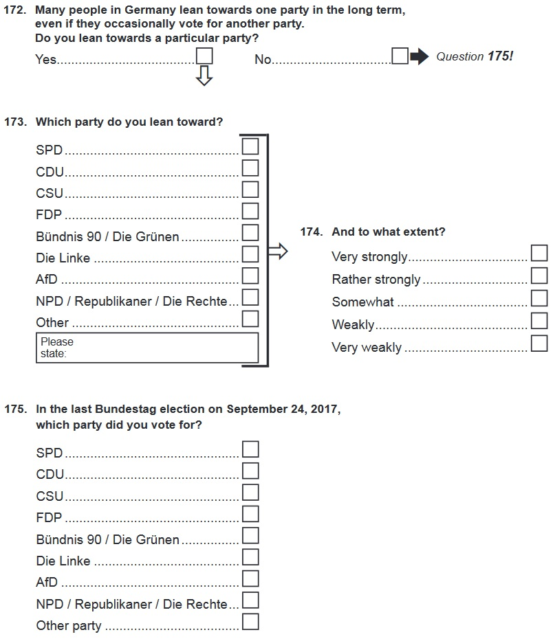

## Example No. 2

- Pairfam 10th wave, 2017/2018

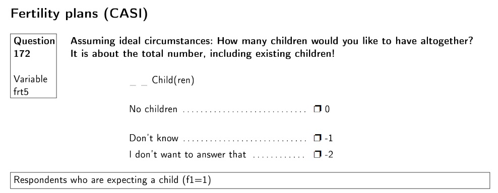

## Example No. 3

-National Educational Panel Study, 6th wave, Newborn Cohort 2017

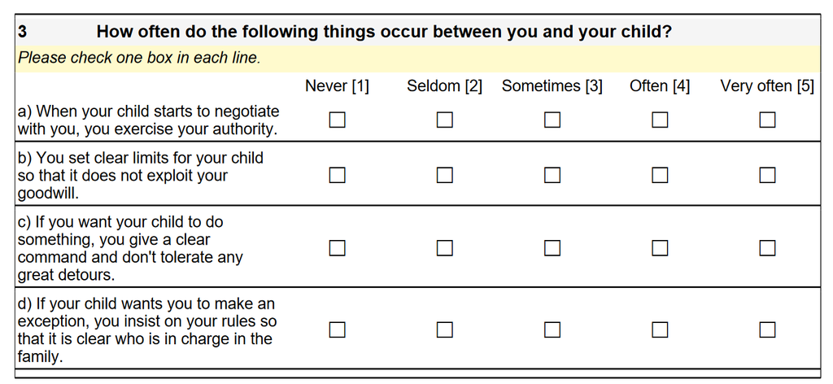

## How about our own survey?

- I would like to make a mock-survey of students in this class

### Collect information

- It will take between five to ten minutes
- [Go to this link](https://docs.google.com/forms/d/e/1FAIpQLSdU-M1oU37Iq4uc8h8XPpe7-axnnmttflw9gfRzIfodf2IIMw/viewform?usp=sf_link)
- 10 min. pause while you answer these important questions

## Content of this Seminar

- Introduction to using R: functions and packages for categorical data (e.g. tidyverse for data cleaning and management)
- But what is a categorical variable anyway: Latent versus observed variables
- Uni-dimensional measures of association
- Multivariate methods: the general linear regression model and friends
- Ordinal data is everywhere
- Prediction problems: supervised and unsupervised context
- Summarizing results: statistics and in Tables or in Figures (plots with ggplot2)

## Reference Book I

- Wickham and Grolemund (2016)
- This is the main reference for learning R
- There is an online version: [R for Data Science](https://r4ds.had.co.nz/)

## Reference Book II

[figure not shown]

- Bilder and Loughin (2014)
- Some theory of CDA + Examples in R
- Main text of the class for CDA

## Reference Book III

[figure not shown]

- Agresti (2002)
- Bibble of CDA
- Mainly theoretical (only to dive in on topic)
- More recent third edition with R examples (just ordered it)

## Reference Book IV

[figure not shown]

- Winkelmann and Boes (2006)
- Microeconometrics
- Highly theoretical, but some topics are well covered
- With a HU account, download *Analysis of Microdata* [Here!](https://www.springer.com/gp/book/9783540927471) *** And a few more references I will be updating as the course advances

## (Flexi)Calendar of Activities

```
      Date    Introduction                        Methods      Projects
1   14-Oct dies academicus                              -             -
2   21-Oct    Intro to CDA                              -             -
3   28-Oct               -  Tidyverse and some statistics             -
4   04-Nov               - More Tidyverse and binary data             -
5   11-Nov               -         Models for binary data             -
6  18-Nov*               -               Multinomial Data             -
7   25-Nov               -                   Ordinal Data             -
8   02-Dec               -                              - Presentations
9   09-Dec               -         Intro to Psychometrics             -
10  16-Dec               -          Latent Class Analysis             -
11  06-Jan               -                       Boosting  Send exposés
12  13-Jan               -                        ggplot2             -
13  20-Jan               -                    Survey Data             -
14  27-Jan               -                   Missing Data             -
15  03-Feb               -                       Hands-on             -
16  10-Feb               -                        Wrap-up             -
```

## Work, work, work, work, work, work…

Students’ tasks…

1. Attend the lectures…
2. Take the quizzes each week…
3. Do their work on class…
4. Work on their own independent projects/research questions
- Presentation (7-10 min presentations + 5 min feedback)
- Exposé (5-10 pages)
- Final paper (20-25 pages (ind.) or around between 30-45 (groups of two))

## Final Project Options

### PISA Study

- Programme for International Student Assessment

### Independent research proposal

### A mixture of the two alternatives

## Structure of a typical lecture

1. Small quiz about previous lesson
2. A motivating problem
3. A method + some statistical theory
4. Assumptions!
5. An application in R
6. DIY in class

### Material for each class

- Script in R with text + code
- Slides
- Chapters of books or reference papers

## Important Information

- Moodle: “Introduction to Categorical Data Analysis in R”
- the secret password: cdastats1920
- Contact me: xlejx.rodsxn@pm.me
- Or in Twitter: [@aleja_stats](https://twitter.com/AlejaStats)

[figure not shown]

## Important Information

### Deadlines

- Presentation of topics: **02.12.2019**
- Exposé due on the **06.01.2020**
- Final paper due on the **14.03.2020**

## Reproducibility

(optional, but strongly encouraged)

- Rmarkdown
- Make fully reproducible reports
- Packages: rmarkdown and knitr
- Combine text, code, data analysis, visualization, and high quality documents (like this presentations)
- All scripts will be written in Rmarkdown

## Any questions

## Anything else you want to learn

## First lesson: R is your friend

## What is R? What is R Studio?

- R is a software for statistical analysis and computing
- R Studio is an interface that helps people program, looks prettier and is more friendlier than the R console

## Installing stuff on your computer

For R:

- Go to: [install R](https://cran.r-project.org/bin/windows/base/) if you have Windows OS
- Go to: [install R](https://cran.r-project.org/bin/macosx/) if you have Mac OS
- For Ubuntu, I am sorry, I cannot help you with this (I tried it myself, and did not succeed)
- Then follow directions…

For R Studio

- Go to: [install R Studio](https://rstudio.com/products/rstudio/download/)
- Then again just follow directions…

## Next time, on Intro to CDA

## R for Data Science

- Read Chapters 1 and 2: Introduction
- A fresh first look at PISA

## Getting your data into R

## Tidy your data and transform it

## Analyze your data

## Visualize your data

## References

Agresti, Alan. 2002. *Categorical Data Analysis*. Wiley.

Bilder, Christopher R, and Thomas M Loughin. 2014. *Analysis of Categorical Data with R*. Chapman; Hall/CRC.

Wickham, Hadley, and Garrett Grolemund. 2016. *R for Data Science: Import, Tidy, Transform, Visualize, and Model Data*. " O’Reilly Media, Inc.".

Winkelmann, Rainer, and Stefan Boes. 2006. *Analysis of Microdata*. Springer Science & Business Media.